# Inaccuracy tests with SPEX

Basically, how bad of an approximation can we do to the interpolation and still get away with 10% accuracy to the grid points? 10K, 0.05 dex in logg and [Fe/H] ?

As a comparison we need a high quality spectrum generated using our normal interpolation methods.

## Conclusion

The SPEX tests are different than the TRES tests. This is because we are going from R=500,000 to R=2000, and thus the convolve first then interpolate will bring out more errors. The interesting thing, though, is that the error from doing convolve-interpolate is a *different spectrum* than the interpolation envelope. This is good. It means that this might be simply like adding interpolation noise (that the GP should pick up) rather than actually adding in any specific bias.

The areas where the HA is much lower than the LA are generally also continuum regions. This is good news, too.

```python
%matplotlib
import matplotlib.pyplot as plt
import numpy as np
from StellarSpectra.spectrum import DataSpectrum
from StellarSpectra.grid_tools import SPEX, HDF5Interface
from StellarSpectra.model import Model
from grid_accuracy import AccuracyComparison

from IPython.display import display
```

```
Using matplotlib backend: Qt4Agg
```

# SPEX Spectra

```python
myDataSpectrum = DataSpectrum.open("../../data/Gl51/Gl51.hdf5")
myInstrument = SPEX()
```

## Perturbations about T=3000, logg=4.5, Z = -0.5

[output not shown]

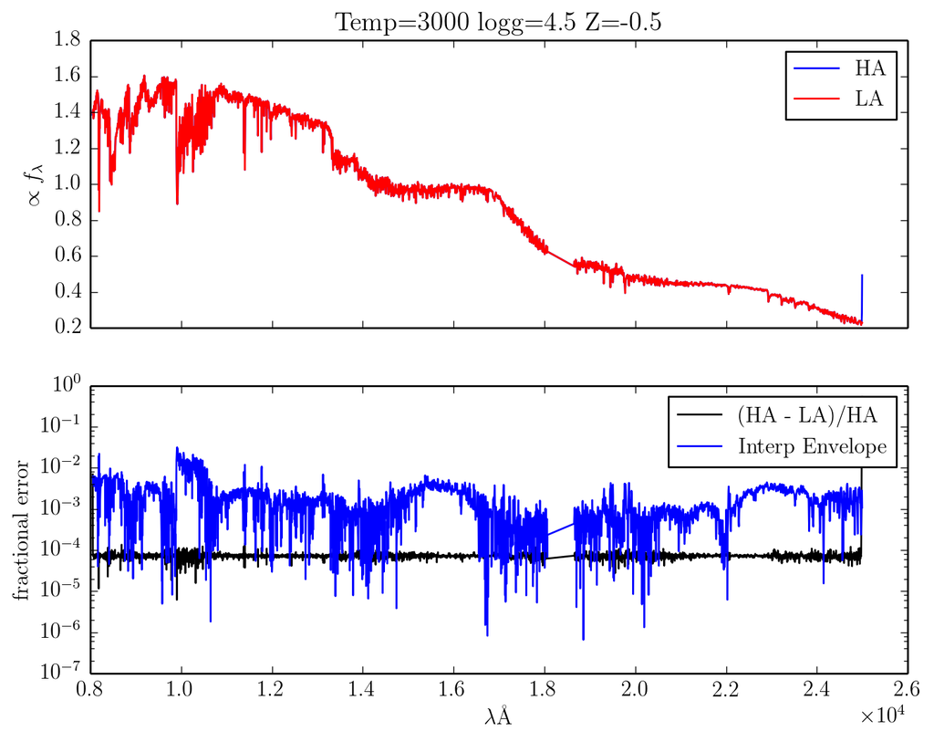

```python
myComp = AccuracyComparison(myDataSpectrum, myInstrument, "../../libraries/PHOENIX_submaster_M.hdf5",
                            "../../libraries/PHOENIX_SPEX_2300.hdf5",
                            {"temp":3000, "logg":4.5, "Z":-0.5}, {"temp":30, "logg":0.1, "Z": 0.1})

fig = myComp.plot_quality()
display(fig)
```

[output not shown]

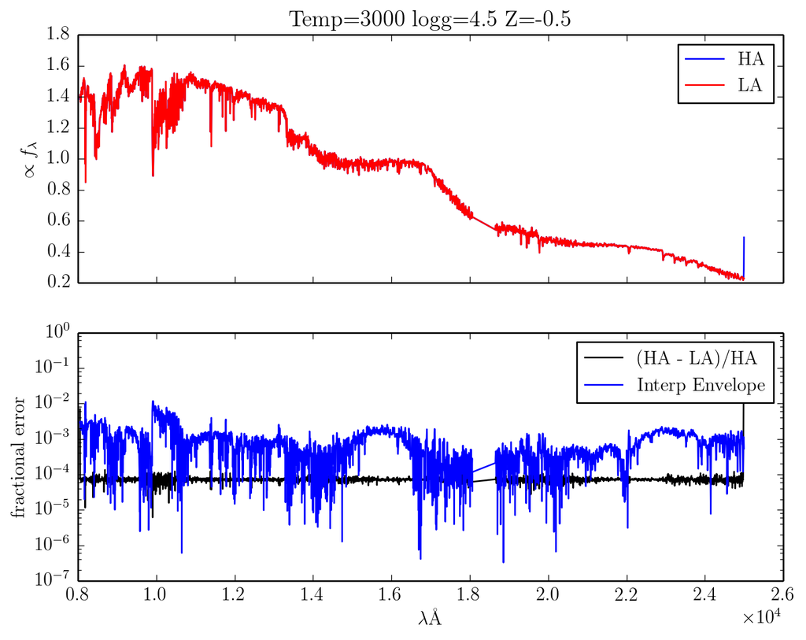

```python
myComp = AccuracyComparison(myDataSpectrum, myInstrument, "../../libraries/PHOENIX_submaster_M.hdf5",
                            "../../libraries/PHOENIX_SPEX_2300.hdf5",
                            {"temp":3000, "logg":4.5, "Z":-0.5}, {"temp":10, "logg":0.05, "Z": 0.05})

fig = myComp.plot_quality()
display(fig)
```

[output not shown]

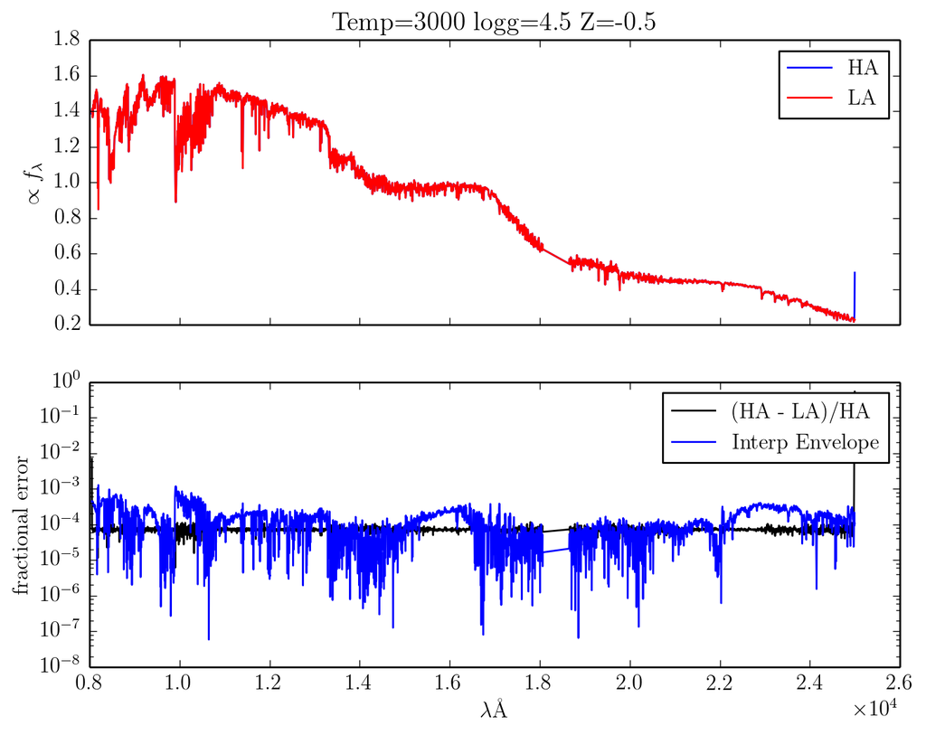

```python
myComp = AccuracyComparison(myDataSpectrum, myInstrument, "../../libraries/PHOENIX_submaster_M.hdf5",
                            "../../libraries/PHOENIX_SPEX_2300.hdf5",
                            {"temp":3000, "logg":4.5, "Z":-0.5}, {"temp":1, "logg":0.01, "Z": 0.01})

fig = myComp.plot_quality()
display(fig)
```

## Perturbations about T=4000, logg=4.5, Z= -0.5

[output not shown]

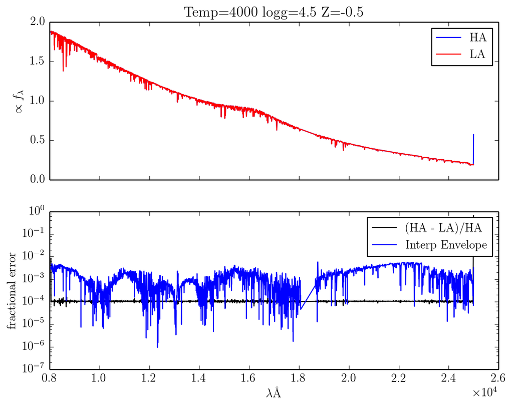

```python
myComp = AccuracyComparison(myDataSpectrum, myInstrument, "../../libraries/PHOENIX_submaster_M.hdf5",
                            "../../libraries/PHOENIX_SPEX_2300.hdf5",
                            {"temp":4000, "logg":4.5, "Z":-0.5}, {"temp":30, "logg":0.1, "Z": 0.1})

fig = myComp.plot_quality()
display(fig)
```

[output not shown]

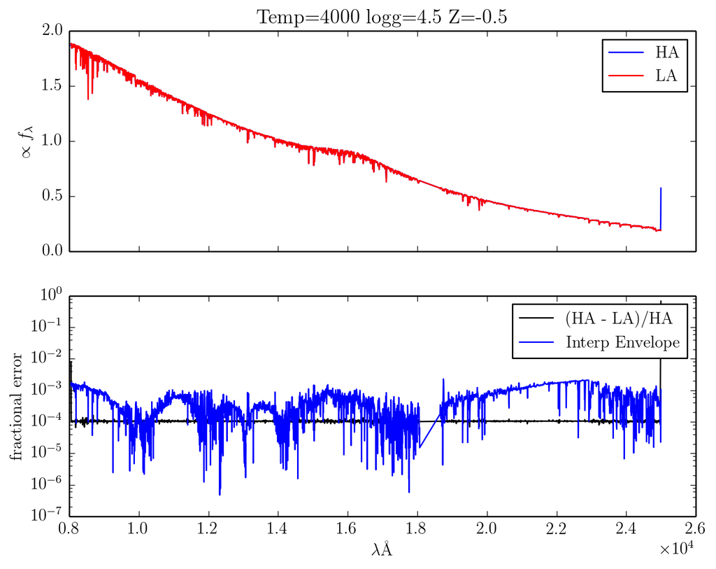

```python
myComp = AccuracyComparison(myDataSpectrum, myInstrument, "../../libraries/PHOENIX_submaster_M.hdf5",
                            "../../libraries/PHOENIX_SPEX_2300.hdf5",
                            {"temp":4000, "logg":4.5, "Z":-0.5}, {"temp":10, "logg":0.05, "Z": 0.05})

fig = myComp.plot_quality()
display(fig)
```

[output not shown]

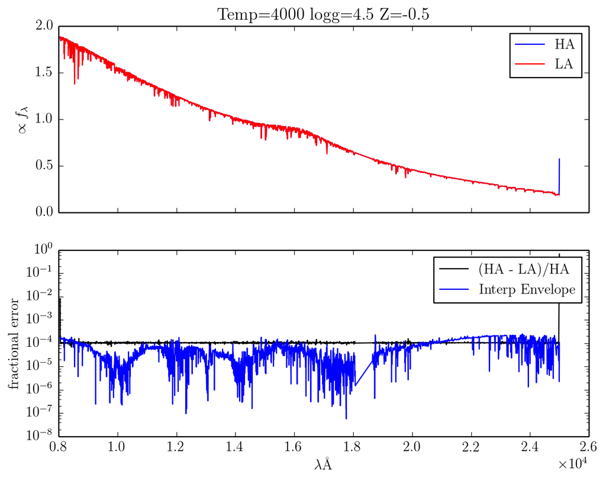

```python
myComp = AccuracyComparison(myDataSpectrum, myInstrument, "../../libraries/PHOENIX_submaster_M.hdf5",
                            "../../libraries/PHOENIX_SPEX_2300.hdf5",
                            {"temp":4000, "logg":4.5, "Z":-0.5}, {"temp":1, "logg":0.01, "Z": 0.01})

fig = myComp.plot_quality()
display(fig)
```